# Usage des vélos de location de la ville de Washington D.C.

Auteur·rice

Paul Coffi

## Packages

L’étude ci-dessous nécessite les paquets suivants:

```r
# Listez tous les packages utilisés
library(tidyverse) # Pour la manipulation des données
library(corrplot)
library(emmeans)
library(car)
library(gridExtra)
```

## Données

L’objectif de l’étude est de déterminer

- Quels sont les facteurs les plus influents sur l’utilisation du vélo à Washington, et comment ces facteurs impactent l’usage du vélo.
- Si il existe une configuration de facteurs où l’utilisation des vélos serait maximale;
- Pour une configuration donnée, peut on fournir un intervalle de confiance à 95% sur le nombre de vélos qui seraient loués ce jour là?

On a deux types de variables:

- Les variables quantitatives: temp, hum, windspeed
- Les variables qualitatives: yr,season, month, day, hr, holiday, weekday, workingday, weathersit

```r
donnees= read.csv("donnees_velo.txt", sep=";")
donnees= as_tibble(donnees)
```

## 1. Analyse exploratoire des données

Dans un premier temps, nous allons transformer les colonnes yr,season, month, day, hr, holiday, weekday, workingday, weathersit en facteur et traduire toutes les colonnes.

```r
#| code-fold: show
donnees_new= as_tibble(donnees)|>
  mutate(hr= as.factor(hr), season= as.factor(season), mnth=as.factor(mnth), holiday= as.factor(holiday), weekday= as.factor(weekday), workingday= as.factor(workingday), weathersit= as.factor(weathersit)) |>
  rename(saison= season,annee= yr,mois= mnth,heure= hr,férié= holiday, jour_de_la_semaine=weekday, jour_de_travail=workingday, météo= weathersit,température= temp,humidité= hum,vitesse_du_vent= windspeed, occasionnel=casual ,enregistré=registered,total= cnt)
```

### *1.1 Variables quantitatives*

Pour les variables quantitatives, nous allons créer la matrice de corrélation afin de dégager les corrélations qui puissent exister entre les variables quantitatives et entre les variables explicatives et la variable cible: Le nombre de vélos utilisés qui se décompose en 2 catégories(utilisateurs enregistrés et utilisateurs occasionnels)

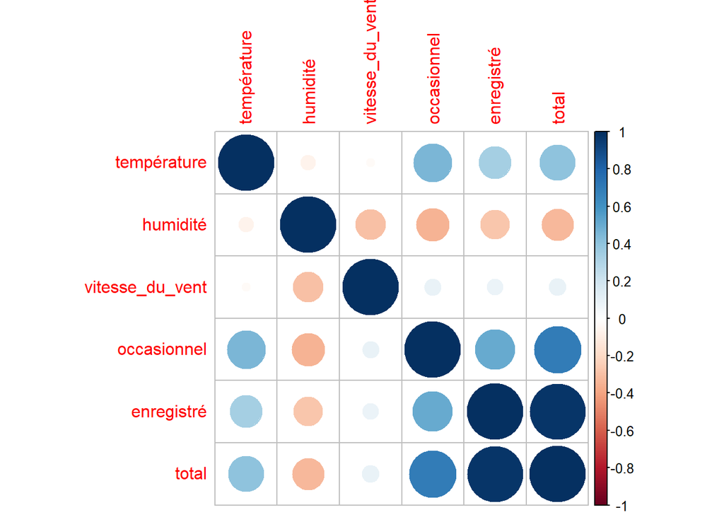

```r
variable_quantitative= donnees_new |>
  select(température, humidité, vitesse_du_vent, occasionnel, enregistré, total)

matrice_correlation= cor(variable_quantitative)

corrplot(matrice_correlation)
```

On remarque qu’il n’y a pas de multicolinéarité entre les variables car les corrélations entre les variables ne sont pas très élevées.

Entre les variables quantitatives, on observe une corrélation linéaire :

- Négative entre l’humidité et et la vitesse du vent(-0.29)

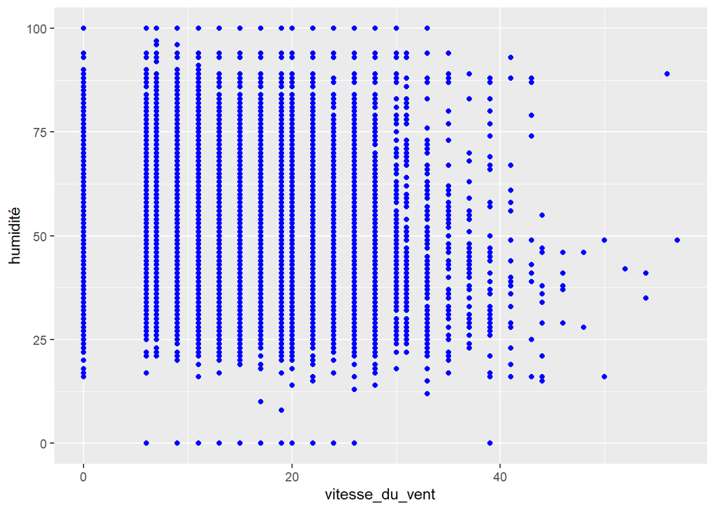

  ```r
  ggplot(donnees_new) +
    aes(x= vitesse_du_vent, y= humidité)+
    geom_point(colour= 'blue')
  ```

- Presque nul: entre la température et l’humidité(-0.06), on va effectuer un test pour savoir si la corrélation est significativement differente de 0 ou non.

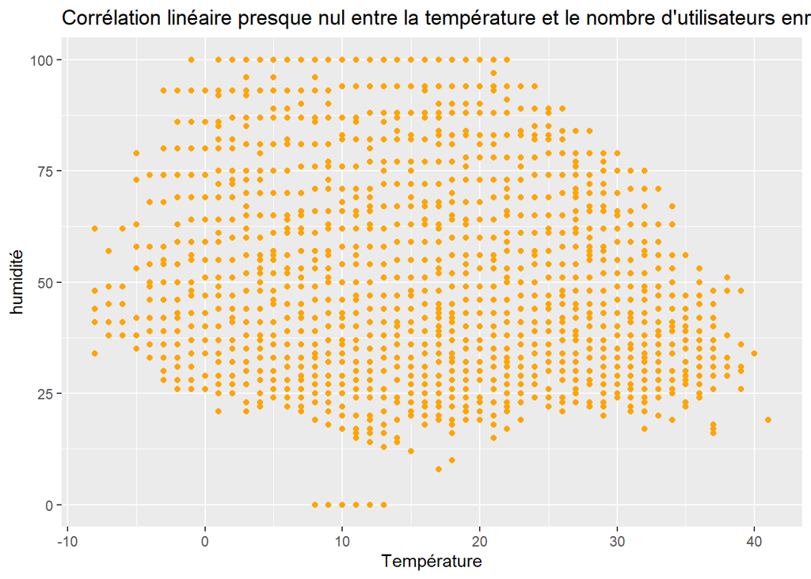

  ```r
  ggplot(donnees_new) +
    aes(température, y= humidité)+
    geom_point(colour= 'orange')+
      labs(x="Température","humidité",title = "Corrélation linéaire presque nul entre la température et le nombre d'utilisateurs enregistrés")
  ```

```r
attach(donnees_new)
cor.test(température, humidité)
```

```
    Pearson's product-moment correlation

data:  température and humidité
t = -9.2345, df = 17377, p-value < 2.2e-16
alternative hypothesis: true correlation is not equal to 0
95 percent confidence interval:
 -0.08466104 -0.05507100
sample estimates:
        cor
-0.06988139
```

```r
detach(donnees_new)
```

Entre les variables quantitatives et les variables cibles(total, enregistré, occasionnel), on observe:

- Une **corrélation linéaire positive** entre la **température** et les **variables cibles**, mais **un peu plus forte par rapport à la variable occasionnel** ce qui veut dire que **une augmentation de la température a un effet sur le nombre d’utilisateurs occasionnels**

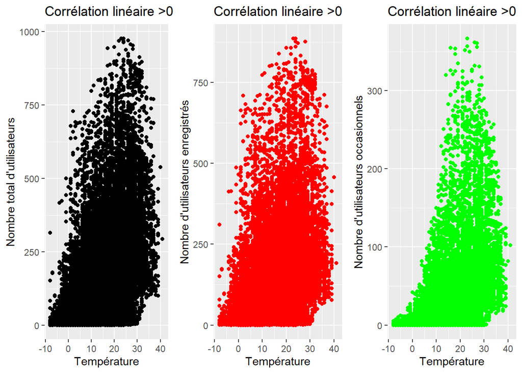

  ```r
     plot1= ggplot(donnees_new) +
    aes(x= température, y= total) +
    geom_point()+
    labs(x="Température",y="Nombre total d'utilisateurs",title = "Corrélation linéaire >0")

  plot2=ggplot(donnees_new) +
    aes(x= température, y= enregistré) +
    geom_point(colour='red') +
    labs(x="Température",y="Nombre d'utilisateurs enregistrés",title = "Corrélation linéaire >0")

  plot3=ggplot(donnees_new) +
    aes(x= température, y= occasionnel) +
    geom_point(colour='green')+
      labs(x="Température",y="Nombre d'utilisateurs occasionnels",title = "Corrélation linéaire >0")
    grid.arrange(plot1, plot2, plot3, nrow = 1)
  ```

- **Une corrélation linéaire négative** entre l’**humidité** et les **variables cibles**, mais **un peu plus faible par rapport à la variable enregistré** ce qui veut dire que l**’humidité a aussi plus d’effets sur les utilisateurs occasionnels**

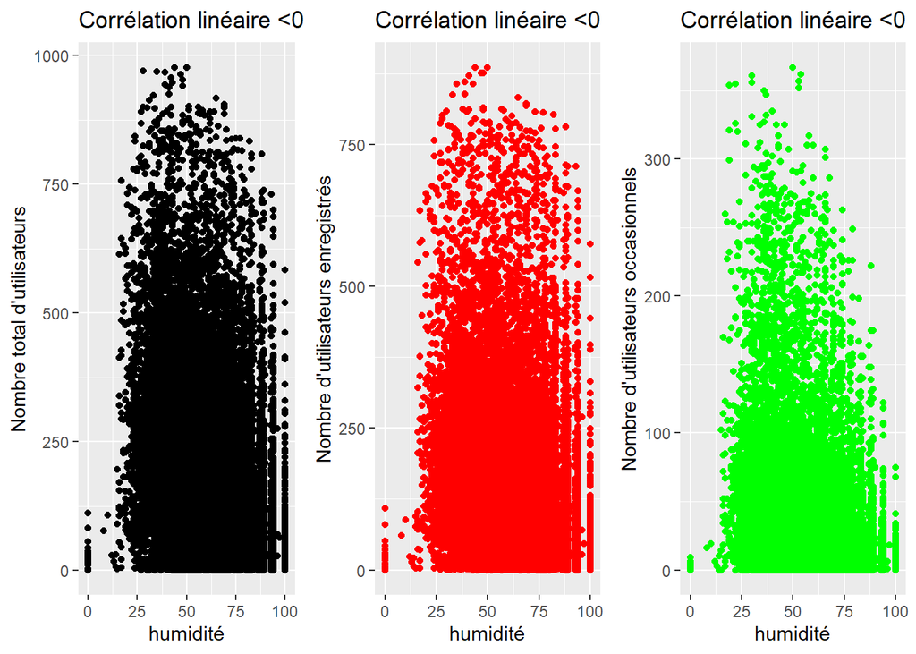

  ```r
  #| code-fold: show

  plot4=ggplot(donnees_new) +
    aes(x= humidité, y= total) +
    geom_point()+
    labs(x="humidité",y="Nombre total d'utilisateurs",title = "Corrélation linéaire <0")

  plot5= ggplot(donnees_new) +
    aes(x= humidité, y= enregistré) +
    geom_point(colour='red') +
    labs(x="humidité",y="Nombre d'utilisateurs enregistrés",title = "Corrélation linéaire <0")

  plot6= ggplot(donnees_new) +
    aes(x= humidité, y= occasionnel) +
    geom_point(colour='green')+
      labs(x="humidité",y="Nombre d'utilisateurs occasionnels",title = "Corrélation linéaire <0")

  grid.arrange(plot4, plot5, plot6, nrow = 1)
  ```

**Une corrélation linéaire presque nulle** entre la vitesse du vent et la variable cible: En supposant que les deux variables sont distribuées de maniere **normale**, **on fera un test pour savoir si la corrélation est significativement differente de 0.** En supposant que les deux variables sont distribuées de maniere normale.

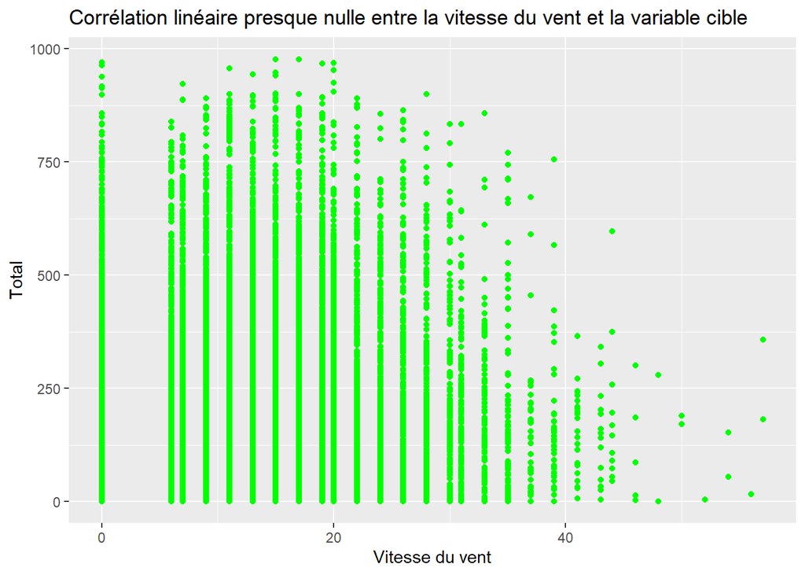

```r
#| code-fold: show
ggplot(donnees_new) +
  aes(x= vitesse_du_vent, y= total) +
  geom_point(colour='green')+
  labs(x="Vitesse du vent", y="Total", title = "Corrélation linéaire presque nulle entre la vitesse du vent et la variable cible")
```

```r
#| code-fold: show
attach(donnees_new)
cor.test(x= vitesse_du_vent,y= total)
```

```
    Pearson's product-moment correlation

data:  vitesse_du_vent and total
t = 12.344, df = 17377, p-value < 2.2e-16
alternative hypothesis: true correlation is not equal to 0
95 percent confidence interval:
 0.07847495 0.10795176
sample estimates:
       cor
0.09323378
```

```r
detach(donnees_new)
```

### *1.1 Variables qualitatives*

On cherche maintenant à expliquer les effets entre les niveaux de chaque facteur sur l’utilisation des vélos: season, day, hr, holiday, weekday, workingday, weathersit.

- Tout d’abord, nous allons vérifier s’il existe une différence entre les moyennes d’utilisation de vélos pour chaque saison.

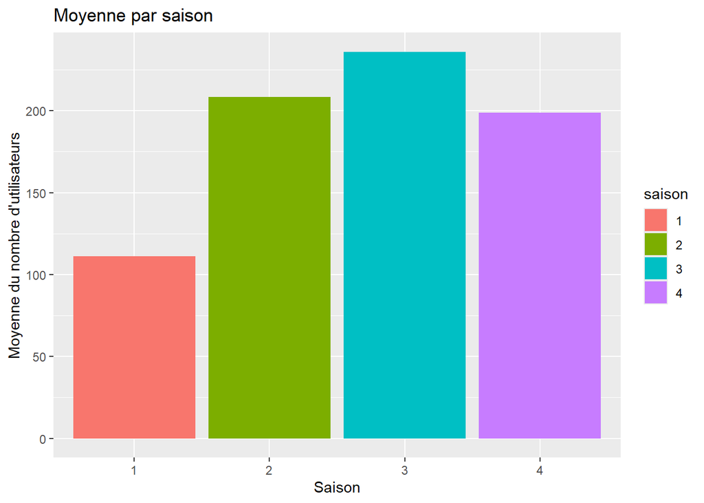

  ```r
  agg1= donnees_new |>
    group_by(saison) |>
    summarise(moyenne_par_saison= mean(total))
  ggplot(agg1) +
    aes(x= saison, y= moyenne_par_saison, fill=saison ) +
    geom_bar(stat = 'identity') +
    labs(x= 'Saison', y= "Moyenne du nombre d'utilisateurs", title= 'Moyenne par saison' )
  ```

  Un premier essai nous a montré qu’il est préférable d’expliquer plutot la racine de la variable cible pour se rapprocher des hypothèses de normalité.

  On compare les moyennes de entre chaque groupe après avoir ajusté le modèle:

  ```r
  #| code-fold: show
  # Ajustement du modèle d'ANOVA
  modele1 <- lm(sqrt(total) ~ saison, data = donnees_new)
  emmeans(object = modele1, specs = "saison") %>% # Calcul des moyennes par groupe
    contrast(method = "pairwise", adjust = "bonferroni") # Tests de comparaison
  ```

  ```
   contrast          estimate    SE    df t.ratio p.value
   saison1 - saison2   -3.613 0.139 17375 -25.899  <.0001
   saison1 - saison3   -4.652 0.139 17375 -33.504  <.0001
   saison1 - saison4   -3.336 0.141 17375 -23.676  <.0001
   saison2 - saison3   -1.039 0.137 17375  -7.556  <.0001
   saison2 - saison4    0.276 0.140 17375   1.981  0.2858
   saison3 - saison4    1.315 0.139 17375   9.467  <.0001

  Note: contrasts are still on the sqrt scale. Consider using
        regrid() if you want contrasts of back-transformed estimates.
  P value adjustment: bonferroni method for 6 tests
  ```

  Pour le premier test, on observe une difference de moyenne du nombre d’utilisateurs total entre printemps et été, printemps et automne, printemps et hiver, été été et automne, automne et hiver. Mais la difference n’est pas claire entre l’hiver et l’été.

  On va réaliser une ANOVA pour vérifier cela. Le modèle d’ANOVA à un facteur est donné par :

$$Yij=μ+τi+ϵij$$

où :

- $(Yij)$ est la racine carrée du nombre de vélo observée pour l’individu (j) dans le groupe (i). -
- $(μ)$ est la moyenne globale.
- $(τi)$ est l’effet du (i)-ème groupe (saison).
- $(ϵij)$ est l’erreur aléatoire, supposée suivre une distribution normale.

  **Hypothèse Nulle** :

$$H0:μsaison1=μsaison2=μsaison3=…=μsaisonk$$
**Contre l’hypothèse alternative**:

$$éH1:Au moins une μsaisoni est différente.$$

```r
    car::Anova(modele1)
```

```
Anova Table (Type II tests)

Response: sqrt(total)
          Sum Sq    Df F value    Pr(>F)
saison     52498     3  415.94 < 2.2e-16 ***
Residuals 730990 17375
---
Signif. codes:  0 '***' 0.001 '**' 0.01 '*' 0.05 '.' 0.1 ' ' 1
```

```
les deux tests montrent qu'il existe au moins une différence de moyenne entre les différentes saisons.

On va vérifier si les tests réalisés respectent les hypothèses de normalité des résidus , d'homogénéité des variances des résidus en supposant l'indépendance des résidus.
```

- **Test de normalité**

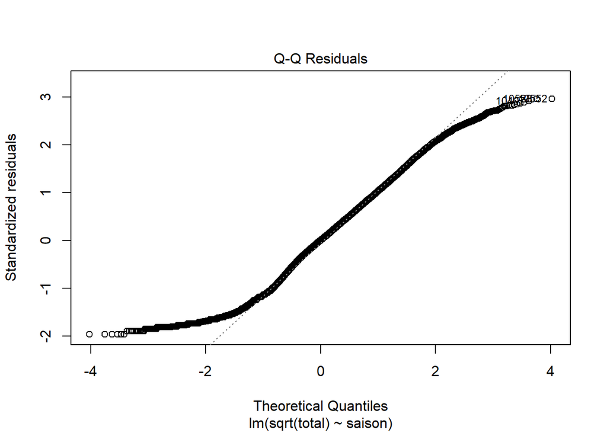

  ```r
  plot(modele1, 2)
  ```

  D’apres le graphique, les résidus sont presque aligné autour de la ligne.
- **Test d’homogénéité de la variance**

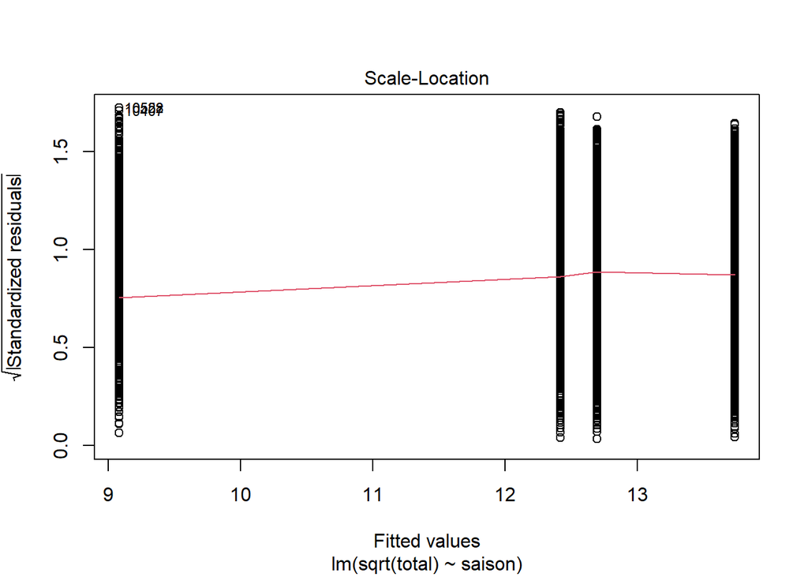

  ```r
  #| code-fold: show
  plot(modele1, 3)
  ```

  On remarque que la variance est presque la meme dans chaque groupe.
- Nous allons vérifier s’il existe une difference de moyenne de nombre d’utilisateurs par heure

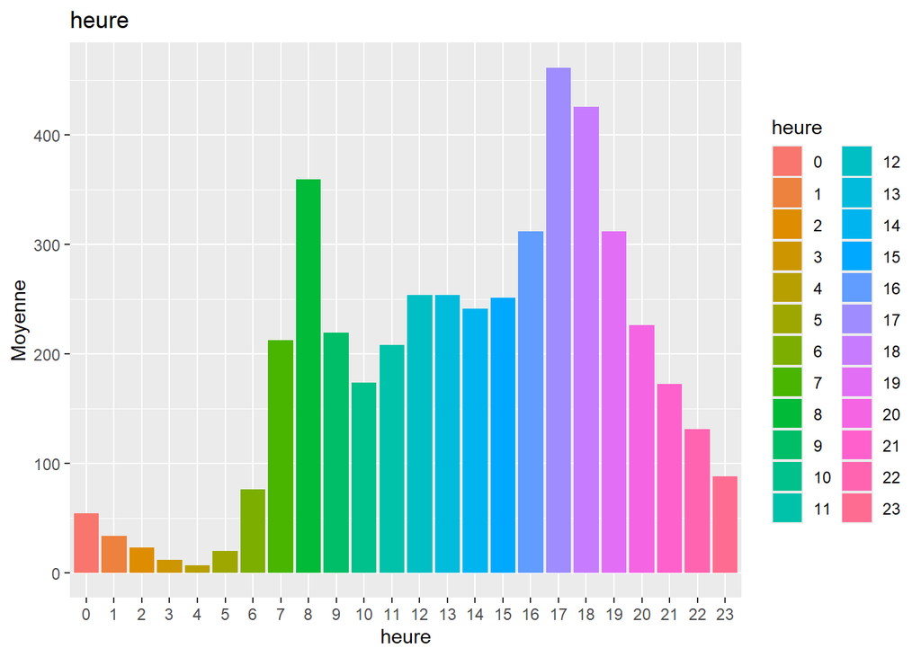

  ```r
  #| code-fold: show

  agg2= donnees_new |>
    group_by(heure) |>
    summarise(moyenne_par_heure= mean(total))
  ggplot(agg2) +
    aes(x= heure, y= moyenne_par_heure, fill=heure ) +
    geom_bar(stat = 'identity') +
    labs(x= 'heure', y= 'Moyenne', title= 'heure' )
  ```

```r
modele2 <- lm(sqrt(total) ~ heure, data = donnees_new)
car::Anova(modele1)
```

[output not shown]

**Vérification des hypothèses de l’ANOVA**

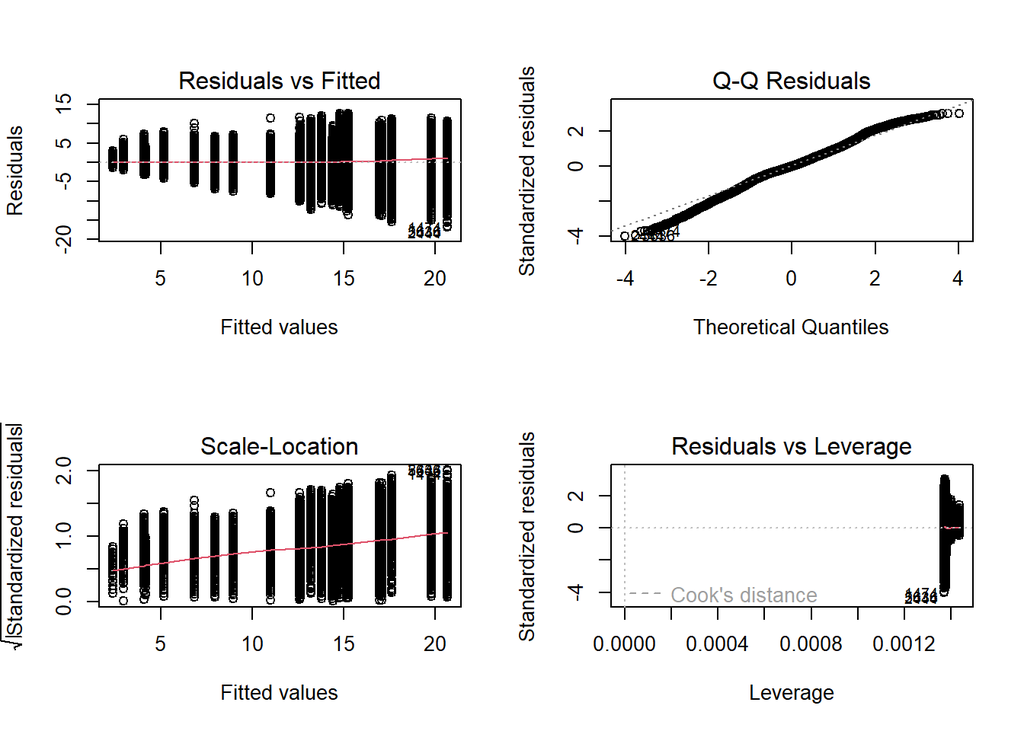

```r
par(mfrow=c(2,2))
plot(modele2)
```

- Nous allons vérifier s’il existe une difference de moyenne de nombre d’utilisateurs en fonction du fait que le jour soit ouvré ou non.

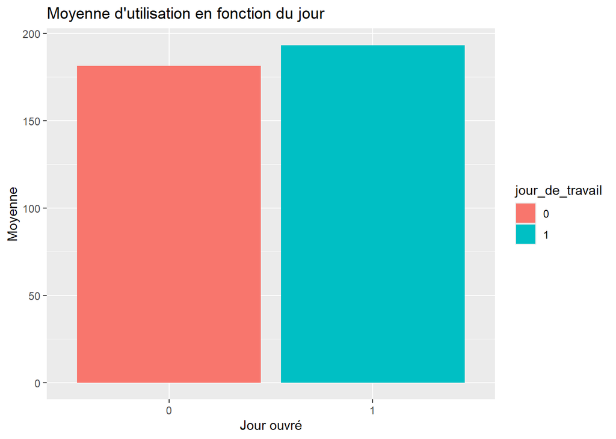

  ```r
  #| code-fold: show

  agg3= donnees_new |>
    group_by(jour_de_travail) |>
    summarise(moyenne_par_jt= mean(total))
  ggplot(agg3) +
    aes(x= jour_de_travail, y= moyenne_par_jt, fill=jour_de_travail ) +
    geom_bar(stat = 'identity') +
    labs(x= 'Jour ouvré', y= 'Moyenne', title= "Moyenne d'utilisation en fonction du jour" )
  ```

  Le graphique ci-dessus nous laisse penser que la différence entre les deux groupes n’est pas significative.

  Nous allons réaliser une ANOVA à un facteur pour vérifier cela.

  ```r
  modele3 <- lm(sqrt(total) ~ jour_de_travail, data = donnees_new)
  car::Anova(modele3)
  ```

  ```
  Anova Table (Type II tests)

  Response: sqrt(total)
                  Sum Sq    Df F value  Pr(>F)
  jour_de_travail    447     1  9.9169 0.00164 **
  Residuals       783040 17377
  ---
  Signif. codes:  0 '***' 0.001 '**' 0.01 '*' 0.05 '.' 0.1 ' ' 1
  ```

  Nous allons vérifier si les hypothèses de l’ANOVA sont respectées.

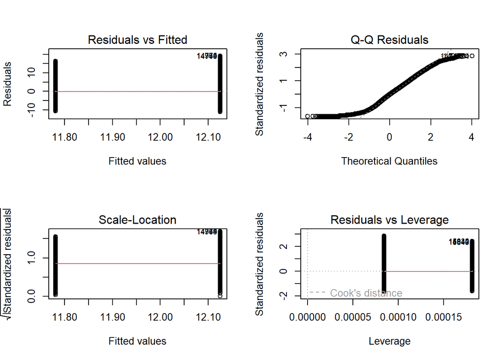

  ```r
  par(mfrow=c(2,2))
  plot(modele3)
  ```

  D’apres les graphiques, les hypothèses sont vérifiées. Il y’a donc une différence significative de moyenne de nombres d’utilisateurs entre les jours ouvrés et les jours non ouvrés.
- Nous allons vérifier s’il existe une difference de moyenne de nombre d’utilisateurs en fonction de la météo

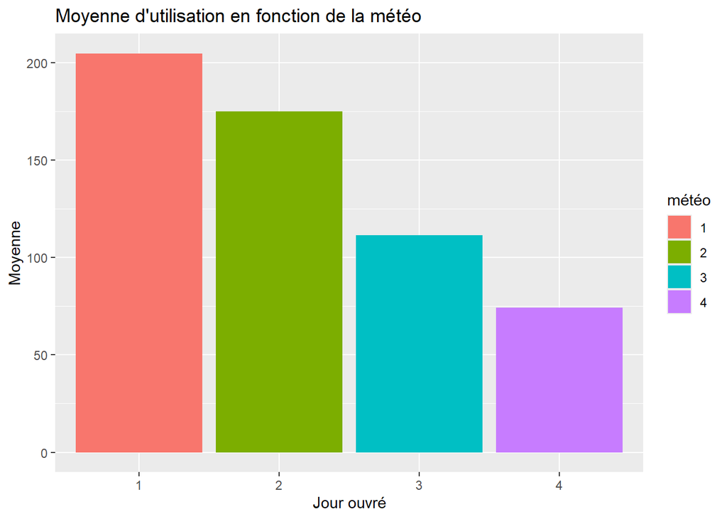

  ```r
  #| code-fold: show

  agg4= donnees_new |>
    group_by(météo) |>
    summarise(moyenne_par_météo= mean(total))
  ggplot(agg4) +
    aes(x= météo, y= moyenne_par_météo, fill= météo ) +
    geom_bar(stat = 'identity') +
    labs(x= 'Jour ouvré', y= 'Moyenne', title= "Moyenne d'utilisation en fonction de la météo" )
  ```

On voit très clairement qu’il y’a une différence entre les moyennes d’utilisations en fonction de la météo.

Nous allons confirmer cela avec une ANOVA à 1 facteur.

```r
modele4 <- lm(sqrt(total) ~ météo, data = donnees_new)
car::Anova(modele4)
```

```
Anova Table (Type II tests)

Response: sqrt(total)
          Sum Sq    Df F value    Pr(>F)
météo      17558     3  132.77 < 2.2e-16 ***
Residuals 765929 17375
---
Signif. codes:  0 '***' 0.001 '**' 0.01 '*' 0.05 '.' 0.1 ' ' 1
```

D’apres le test, il y’a une difference entre les moyennes d’utilisations par météo.

**Vérification des hypothèses de l’ANOVA**

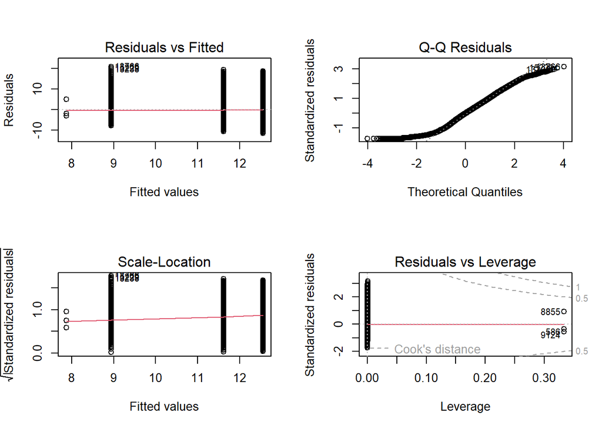

```r
par(mfrow=c(2,2))
plot(modele4)
```

D’apres les graphiques les hypothèses sont vraies, il y’a une difference entre les moyennes d’utilisations en fonction de la météo.

## 2. Le modele linéaire

L’erreur résiduelle suit une loi normale :

$$ϵ∼N(0,σ2)$$

```r
modele_lin= lm(log(total)~ température+ humidité+ vitesse_du_vent+ annee+ saison+ mois+ heure+ jour_de_la_semaine+ météo, data= donnees_new)
```

On estime les paramètres ensuite:

```r
summary(modele_lin)
```

```
Call:
lm(formula = log(total) ~ température + humidité + vitesse_du_vent +
    annee + saison + mois + heure + jour_de_la_semaine + météo,
    data = donnees_new)

Residuals:
    Min      1Q  Median      3Q     Max
-4.3070 -0.3018  0.0303  0.3807  2.5240

Coefficients:
                      Estimate Std. Error t value Pr(>|t|)
(Intercept)          2.9083795  0.0390293  74.518  < 2e-16 ***
température          0.0289193  0.0011540  25.060  < 2e-16 ***
humidité            -0.0025958  0.0003406  -7.620 2.66e-14 ***
vitesse_du_vent     -0.0037179  0.0006276  -5.924 3.20e-09 ***
annee                0.4726294  0.0096054  49.205  < 2e-16 ***
saison2              0.3201943  0.0298391  10.731  < 2e-16 ***
saison3              0.3784405  0.0353267  10.713  < 2e-16 ***
saison4              0.6252057  0.0299018  20.909  < 2e-16 ***
mois2                0.1155664  0.0240803   4.799 1.61e-06 ***
mois3                0.1372410  0.0270350   5.076 3.89e-07 ***
mois4                0.0911137  0.0402355   2.265 0.023555 *
mois5                0.2232543  0.0430342   5.188 2.15e-07 ***
mois6                0.1173102  0.0441554   2.657 0.007897 **
mois7               -0.0359397  0.0496050  -0.725 0.468757
mois8                0.0324597  0.0482041   0.673 0.500714
mois9                0.1186150  0.0429755   2.760 0.005785 **
mois10               0.0356542  0.0398245   0.895 0.370648
mois11              -0.0590155  0.0382414  -1.543 0.122792
mois12              -0.0418838  0.0304309  -1.376 0.168729
heure1              -0.6277098  0.0328508 -19.108  < 2e-16 ***
heure2              -1.1663007  0.0329658 -35.379  < 2e-16 ***
heure3              -1.7501170  0.0332042 -52.708  < 2e-16 ***
heure4              -2.0454113  0.0332375 -61.539  < 2e-16 ***
heure5              -0.9545388  0.0330219 -28.906  < 2e-16 ***
heure6               0.2635578  0.0329350   8.002 1.30e-15 ***
heure7               1.2480599  0.0328701  37.969  < 2e-16 ***
heure8               1.8834391  0.0328298  57.370  < 2e-16 ***
heure9               1.5668800  0.0328642  47.677  < 2e-16 ***
heure10              1.2395720  0.0330013  37.561  < 2e-16 ***
```

[output cut: 13 more lines]

```
jour_de_la_semaine1 -0.0613800  0.0177557  -3.457 0.000548 ***
jour_de_la_semaine2 -0.0575830  0.0178432  -3.227 0.001253 **
jour_de_la_semaine3 -0.0441740  0.0178155  -2.480 0.013165 *
jour_de_la_semaine4  0.0053723  0.0178205   0.301 0.763060
jour_de_la_semaine5  0.1055723  0.0177439   5.950 2.74e-09 ***
jour_de_la_semaine6  0.0998759  0.0176854   5.647 1.65e-08 ***
météo2              -0.0455849  0.0117931  -3.865 0.000111 ***
météo3              -0.5919077  0.0198569 -29.809  < 2e-16 ***
météo4              -0.0676768  0.3619444  -0.187 0.851678
---
Signif. codes:  0 '***' 0.001 '**' 0.01 '*' 0.05 '.' 0.1 ' ' 1

Residual standard error: 0.6253 on 17328 degrees of freedom
Multiple R-squared:  0.8235,    Adjusted R-squared:  0.823
F-statistic:  1617 on 50 and 17328 DF,  p-value: < 2.2e-16
```

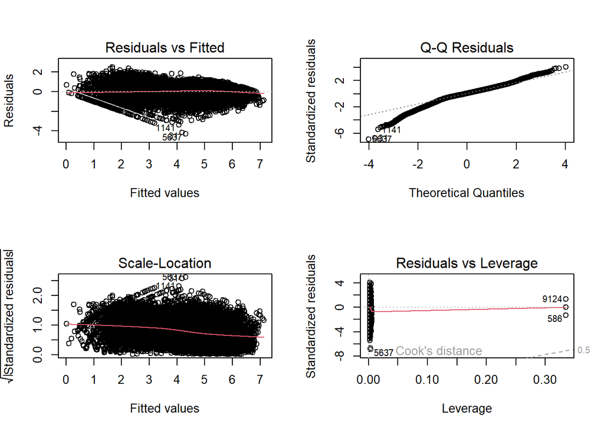

```r
par(mfrow=c(2,2))
plot(modele_lin)
```

Ensuite nous allons utiliser l’ANOVA de type 2 pour tester les effets des variables du modèle.

```r
car::Anova(modele_lin)
```

```
Anova Table (Type II tests)

Response: log(total)
                    Sum Sq    Df  F value    Pr(>F)
température          245.5     1  628.028 < 2.2e-16 ***
humidité              22.7     1   58.071 2.659e-14 ***
vitesse_du_vent       13.7     1   35.094 3.202e-09 ***
annee                946.6     1 2421.102 < 2.2e-16 ***
saison               183.5     3  156.430 < 2.2e-16 ***
mois                  61.3    11   14.261 < 2.2e-16 ***
heure              19451.8    23 2163.183 < 2.2e-16 ***
jour_de_la_semaine    73.6     6   31.388 < 2.2e-16 ***
météo                358.4     3  305.574 < 2.2e-16 ***
Residuals           6774.7 17328
---
Signif. codes:  0 '***' 0.001 '**' 0.01 '*' 0.05 '.' 0.1 ' ' 1
```

On constate que toutes les variables du modèle sont significatives et que R2 nous suggère que le modèle est assez bon pour prédire la variable cible.

## 3. Existe t-il une configuration de facteurs où l’utilisation des vélos serait maximal ?

Pour répondre à cette question, nous allons étudier le signe des paramètres estimés pour chaque variable explicative.

```r
summary(modele_lin)
```

```
Call:
lm(formula = log(total) ~ température + humidité + vitesse_du_vent +
    annee + saison + mois + heure + jour_de_la_semaine + météo,
    data = donnees_new)

Residuals:
    Min      1Q  Median      3Q     Max
-4.3070 -0.3018  0.0303  0.3807  2.5240

Coefficients:
                      Estimate Std. Error t value Pr(>|t|)
(Intercept)          2.9083795  0.0390293  74.518  < 2e-16 ***
température          0.0289193  0.0011540  25.060  < 2e-16 ***
humidité            -0.0025958  0.0003406  -7.620 2.66e-14 ***
vitesse_du_vent     -0.0037179  0.0006276  -5.924 3.20e-09 ***
annee                0.4726294  0.0096054  49.205  < 2e-16 ***
saison2              0.3201943  0.0298391  10.731  < 2e-16 ***
saison3              0.3784405  0.0353267  10.713  < 2e-16 ***
saison4              0.6252057  0.0299018  20.909  < 2e-16 ***
mois2                0.1155664  0.0240803   4.799 1.61e-06 ***
mois3                0.1372410  0.0270350   5.076 3.89e-07 ***
mois4                0.0911137  0.0402355   2.265 0.023555 *
mois5                0.2232543  0.0430342   5.188 2.15e-07 ***
mois6                0.1173102  0.0441554   2.657 0.007897 **
mois7               -0.0359397  0.0496050  -0.725 0.468757
mois8                0.0324597  0.0482041   0.673 0.500714
mois9                0.1186150  0.0429755   2.760 0.005785 **
mois10               0.0356542  0.0398245   0.895 0.370648
mois11              -0.0590155  0.0382414  -1.543 0.122792
mois12              -0.0418838  0.0304309  -1.376 0.168729
heure1              -0.6277098  0.0328508 -19.108  < 2e-16 ***
heure2              -1.1663007  0.0329658 -35.379  < 2e-16 ***
heure3              -1.7501170  0.0332042 -52.708  < 2e-16 ***
heure4              -2.0454113  0.0332375 -61.539  < 2e-16 ***
heure5              -0.9545388  0.0330219 -28.906  < 2e-16 ***
heure6               0.2635578  0.0329350   8.002 1.30e-15 ***
heure7               1.2480599  0.0328701  37.969  < 2e-16 ***
heure8               1.8834391  0.0328298  57.370  < 2e-16 ***
heure9               1.5668800  0.0328642  47.677  < 2e-16 ***
heure10              1.2395720  0.0330013  37.561  < 2e-16 ***
```

[output cut: 13 more lines]

```
jour_de_la_semaine1 -0.0613800  0.0177557  -3.457 0.000548 ***
jour_de_la_semaine2 -0.0575830  0.0178432  -3.227 0.001253 **
jour_de_la_semaine3 -0.0441740  0.0178155  -2.480 0.013165 *
jour_de_la_semaine4  0.0053723  0.0178205   0.301 0.763060
jour_de_la_semaine5  0.1055723  0.0177439   5.950 2.74e-09 ***
jour_de_la_semaine6  0.0998759  0.0176854   5.647 1.65e-08 ***
météo2              -0.0455849  0.0117931  -3.865 0.000111 ***
météo3              -0.5919077  0.0198569 -29.809  < 2e-16 ***
météo4              -0.0676768  0.3619444  -0.187 0.851678
---
Signif. codes:  0 '***' 0.001 '**' 0.01 '*' 0.05 '.' 0.1 ' ' 1

Residual standard error: 0.6253 on 17328 degrees of freedom
Multiple R-squared:  0.8235,    Adjusted R-squared:  0.823
F-statistic:  1617 on 50 and 17328 DF,  p-value: < 2.2e-16
```

## 4. Pour une configuration donnée, peut on fournir un intervalle de confiance à 95% sur le nombre de vélos qui seraient loués ce jour là?

Nous allons implémenter une fonction qui pour une configuration donnée, nous fournit l’intervalle de confiance à 95% sur le nombre de vélos qui seraient loués ce jour là.

```r
intervalle_de_confiance= function(température, humidité, vitesse_du_vent, annee, saison, mois, heure, jour_de_la_semaine, météo){

new_data= data.frame(
  température, humidité, vitesse_du_vent, annee, saison, mois, heure, jour_de_la_semaine, météo)


new_data= new_data |>
  mutate(saison= factor(saison), météo= factor(météo), mois= factor(mois), heure= factor(heure), jour_de_la_semaine= factor(jour_de_la_semaine))

# Faire des prédictions
predictions_log <- predict(modele_lin, new_data, interval = "confidence")
return(exp(predictions_log))

}
```

Un exemple avec la configuration suivante:

- température=14;
- humidité=44;
- vitesse du vent= 13;
- annee= 1(2012);
- saison= 1;
- mois= 1(janvier);
- heure= 11
- jour_de_la_semaine= 4;
- météo= 3

Pour cette configuration, on s’attend à obtenir 81 utilisateurs avec comme intervalle de confiance:

$[74.89,87.00]$

```r
intervalle_de_confiance(14, 44, 13, 1, 1, 1, 11, 4, 3)
```

```
       fit      lwr      upr
1 80.72382 74.89806 87.00272
```